# Lobster and Salmon for Chris

JCVD

Last ran: 2018-05-01

```r
suppressPackageStartupMessages({
  library(countrycode)
  library(seaaroundus)
  library(tidyverse)
  library(magrittr)
  library(here)
  library(cowplot)
})
```

# Setup

## Load data

```r
FAO_ts <- readRDS(here("data","FAO_data.rds"))
sau <- readRDS(here("raw_data", "SAU", "SAU_data.rds"))
```

```r
FAO_sp_groups <- read.csv(file = here("raw_data","FAO","FAO_spp_groups.csv"), stringsAsFactors = FALSE) %>%
  janitor::clean_names() %>%
  select(species = x3alpha_code, family = family_group, order = order_group) %>%
  mutate(family = taxize::taxize_capwords(family, onlyfirst = T),
         order = taxize::taxize_capwords(order, onlyfirst = T))

# Load FAO species codes lookup table
FAO_sp_codes <- read.csv(file = here("raw_data","FAO","FAO_sp_codes.csv"), stringsAsFactors = FALSE) %>%
  janitor::clean_names() %>%
  select(species = x3alpha_code, common_name = name_en, sci_name = scientific_name) %>%
  left_join(FAO_sp_groups, by = "species") %>%
  mutate(stop = str_locate(string = sci_name, pattern = " ")[, 1],
         genus = substring(text = sci_name, first = 0, last = stop-1)) %>%
  select(order, family, genus, sci_name, common_name, species, family, order)
```

# Getting provisional salmon - lobster daa for Chris

## Get spp from FAO data

Specify the species we want

```r
salmon_species <- c("PIN", "CHI", "SOC", "COH", "SAL")
lobster_species <- c("LMS", "LOA", "LOJ", "LOK", "NUG", "NUJ", "NUR", "SLC")
```

```r
(aq_salmon_genus <- FAO_ts %>%
  filter(species %in% salmon_species,
         source == "Aquaculture") %>%
  group_by(genus, year) %>%
  summarize(quantity = sum(quantity)) %>%
  ungroup() %>%
  group_by(genus) %>%
  summarize(year_start = min(year)) %>%
  ungroup() %>%
  arrange(year_start) %>%
  filter(year_start > 1955))
```

```
## # A tibble: 2 x 2
##   genus        year_start
##   <chr>             <dbl>
## 1 Oncorhynchus      1962.
## 2 Salmo             1964.
```

Get treatment species (salmons)

```r
pre_post <- min(aq_salmon_genus$year_start)

# Make treatment
salmon_ac <- FAO_ts %>%
  filter(species %in% salmon_species,
         source == "Aquaculture") %>%
  group_by(year) %>%
  summarize(aquaculture = sum(quantity)) %>%
  ungroup()

salmons <- FAO_ts %>%
  filter(species %in% salmon_species,
         source == "Catches") %>%
  group_by(year, iso, genus, species, sci_name) %>%
  summarize(quantity = sum(quantity, na.rm = T)) %>%
  ungroup() %>%
  left_join(aq_salmon_genus, by = "genus") %>%
  mutate(group = 1,
         post = ifelse(year <= year_start, 0, 1)) %>%
  left_join(salmon_ac, by = "year") %>%
  mutate(aquaculture = ifelse(is.na(aquaculture), 0, aquaculture)) %>%
  select(year, country = iso, genus, species, sci_name, quantity, aquaculture, post, group, year_start)
```

And controls (lobsters)

```r
lobsters <- FAO_ts %>%
  filter(species %in% lobster_species,
         source == "Catches") %>%
  group_by(year, iso, genus, species, sci_name) %>%
  summarize(quantity = sum(quantity),
            min_year = min(year)) %>%
  ungroup() %>%
  mutate(group = 0,
         year_start = pre_post,
         post = ifelse(year <= year_start, 0, 1),
         aquaculture = 0) %>%
  select(year, country = iso, genus, species, sci_name, quantity, aquaculture, post, group, year_start)
```

## Price data from SAU

We first need to match the species in SAU to the ones in FAO. The problem is that the suckers at SAU don’t have scientific names. For now, we’ll leve this as is in the general database, but can use salmon and lobster until it has a fix (https://github.com/ropensci/seaaroundus/issues/2)

Now lets get price data for lobster and salmon…

First we decide on the species, and create a dictionary to match sau to fao names of each species

```r
sau_salmon_species <- c(
  "atlantic_salmon",
  "pink_salmon",
  "sockeye_salmon",
  "chinook_salmon",
  "coho_salmon"
  )

sau_lobster_species <- c(
  "longlegged_spiny_lobster",
  "mud_spiny_lobster",
  "caribbean_spiny_lobster",
  "scalloped_spiny_lobster",
  "australian_spiny_lobster"
  )

sau2fao_dictionary <- data.frame(sau_species = c(sau_salmon_species, sau_lobster_species),
                                 species = c("SAL", "PIN", "SOC", "CHI", "COH", "LOJ", "LMS", "SLC", "LOK", "LOA"))
```

```r
sau_lobsters_salmon <- sau %>%
  as.tibble() %>%
  filter(species %in% c(sau_lobster_species, sau_salmon_species)) %>%
  rename(sau_species = species) %>%
  left_join(sau2fao_dictionary, by = "sau_species") %>%
  group_by(years, species) %>%
  summarize(landings = sum(landings),
            value = sum(value)) %>%
  ungroup() %>%
  mutate(price_per_ton = value / landings) %>%
  rename(year = years) %>%
  select(year, species, price_per_ton)
```

## Add biomass from stock-assessement from RAM

Load all RAM data

```r
load(here("raw_data", "RAM", "DBdata.RData"))
```

Take the `tb.data` data.frame, which has the timeseries of biomass and turn it into a tidy data.frame. Then, filter by species and group all stocks. The problem is that there are no stock assessments made for spiny lobsters available in the RAM database.

```r
tb <- tb.data %>%
  gather(stock, biomass) %>%
  drop_na() %>%
  mutate(year = rownames(.))
```

## Join everything

```r
data_for_model_salmon_lobster <- rbind(lobsters, salmons) %>%
  filter(!country == "") %>%
  mutate(group_text = ifelse(group == 0, "Lobster", "Salmon"),
         years_since = year - pre_post,
         years_since_tech_improve = year - 1983,
         group = as.factor(group)) %>%
  left_join(sau_lobsters_salmon, by = c("year","species")) %>%
  select(year, years_since, years_since_tech_improve, post, group_text, group, country, species, genus, sci_name, landings = quantity, aquaculture, price_per_ton_wild = price_per_ton)
```

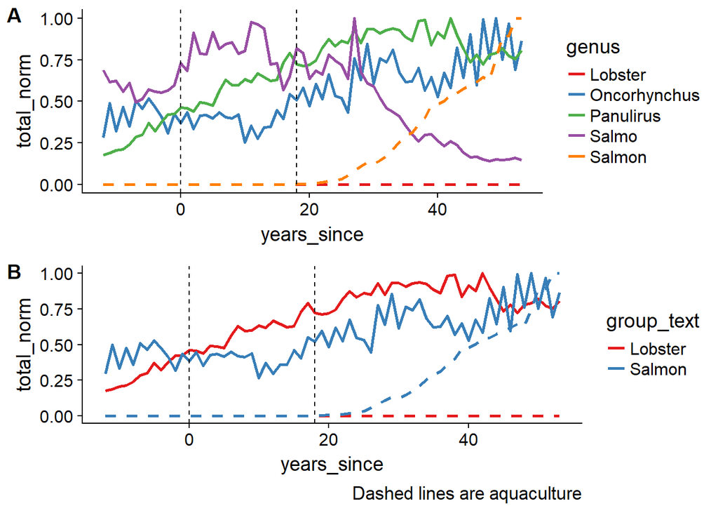

```r
p1 <- data_for_model_salmon_lobster %>%
  group_by(years_since, years_since_tech_improve, group, group_text, genus, aquaculture) %>%
  summarize(total = sum(landings, na.rm = T)) %>%
  ungroup() %>%
  group_by(genus) %>%
  mutate(max = max(total)) %>%
  ungroup() %>%
  mutate(total_norm = total/max) %>%
  ggplot(aes(x = years_since, y = total_norm, color = genus)) +
  geom_line(size = 1) +
  geom_line(aes(y = aquaculture / max(aquaculture), color = group_text), size = 1, linetype = "dashed") +
  scale_color_brewer(palette = "Set1") +
  geom_vline(xintercept = 0, linetype = "dashed") +
  geom_vline(xintercept = 18, linetype = "dashed")

p2 <- data_for_model_salmon_lobster %>%
  group_by(years_since, years_since_tech_improve, group, group_text, aquaculture) %>%
  summarize(total = sum(landings, na.rm = T)) %>%
  ungroup() %>%
  group_by(group) %>%
  mutate(max = max(total)) %>%
  ungroup() %>%
  mutate(total_norm = total/max) %>%
  ggplot(aes(x = years_since, y = total_norm, color = group_text)) +
  geom_line(size = 1) +
  geom_line(aes(y = aquaculture / max(aquaculture), color = group_text), size = 1, linetype = "dashed") +
  scale_color_brewer(palette = "Set1") +
  geom_vline(xintercept = 0, linetype = "dashed") +
  geom_vline(xintercept = 18, linetype = "dashed") +
  labs(caption = "Dashed lines are aquaculture") +
  guides(linetype = guide_legend(keywidth = 3, keyheight = 1))

plot_grid(p1, p2, labels = "AUTO", ncol = 1)
```

Looks good, let’s export the data

```r
write.csv(data_for_model_salmon_lobster, here("data", "data_for_salmon_lobster_model.csv"), row.names = F)
```

## Fit the models

Subindices not provided in models for brevitty

First, only using pre-post in the simplest DiD

$$landings = \beta_0 + \beta_1Group + \beta_2Post + \beta_3 Group\times Post + \epsilon$$

```r
model1 <- lm(log(landings) ~ group * post, data = data_for_model_salmon_lobster)
```

Now we add country fixed effects:

$$landings = \beta_0 + \beta_1Group + \beta_2Post + \beta_3 Group\times Post + \beta_4Country + \epsilon$$

```r
model2 <- lm(log(landings) ~  group * post + country, data = data_for_model_salmon_lobster)
```

Now we add year fixed-effects, but remove country fixed-effects:

$$landings = \beta_0 + \beta_1Group + \beta_2Post + \beta_3 Group\times Post + \beta_4Year + \epsilon$$

```r
model3 <- lm(log(landings) ~  group * post + as.factor(year), data = data_for_model_salmon_lobster)
```

Now we add year fixed-effects, AND country fixed-effects:

$$landings = \beta_0 + \beta_1Group + \beta_2Post + \beta_3 Group\times Post + \beta_4Country + \beta_5Year + \epsilon$$

```r
model4 <- lm(log(landings) ~  group * post + country + as.factor(year), data = data_for_model_salmon_lobster)
```

Now we include a covariate for aquaculture:

$$landings = \beta_0 + \beta_1Group + \beta_2Post + \beta_3 Group\times Post + \beta_4Country + \beta_5Year + \beta_6Aquaculture + \epsilon$$

```r
model5 <- lm(log(landings) ~  group * post + country + as.factor(year) + aquaculture, data = data_for_model_salmon_lobster)
```

Now we include species fixed-effects:

$$landings = \beta_0 + \beta_1Group + \beta_2Post + \beta_3 Group\times Post + \beta_4Country + \beta_5Year + \beta_6Aquaculture + \beta_7Spp + \epsilon$$

```r
model6 <- lm(log(landings) ~  group * post + country + as.factor(year) + aquaculture + species, data = data_for_model_salmon_lobster)
```

Now we add price as a covariate:

$$landings = \beta_0 + \beta_1Group + \beta_2Post + \beta_3 Group\times Post + \beta_4Country + \beta_5Year + \beta_6Aquaculture + \beta_7Spp + \beta_8Price + \epsilon$$

```r
model7 <- lm(log(landings) ~  group * post + country + as.factor(year) + aquaculture + species + price_per_ton_wild, data = data_for_model_salmon_lobster)
```

Now we interact the reatment variable with the years since:

$$landings = \beta_0 + \beta_1Group + \beta_2Years_since + \beta_3 Group\times Years_since + \beta_4Country + \beta_5Year + \beta_6Aquaculture + \beta_7Spp + \epsilon$$

```r
model8 <- lm(log(landings) ~  group * as.factor(years_since) + country + as.factor(year) + aquaculture + species, data = data_for_model_salmon_lobster)
```

And a similar approach, but using years since technological advance instead

```r
model9 <- lm(log(landings) ~  group * as.factor(years_since_tech_improve) + country + as.factor(year) + aquaculture + species, data = data_for_model_salmon_lobster)
```

### Coefficients

For year since

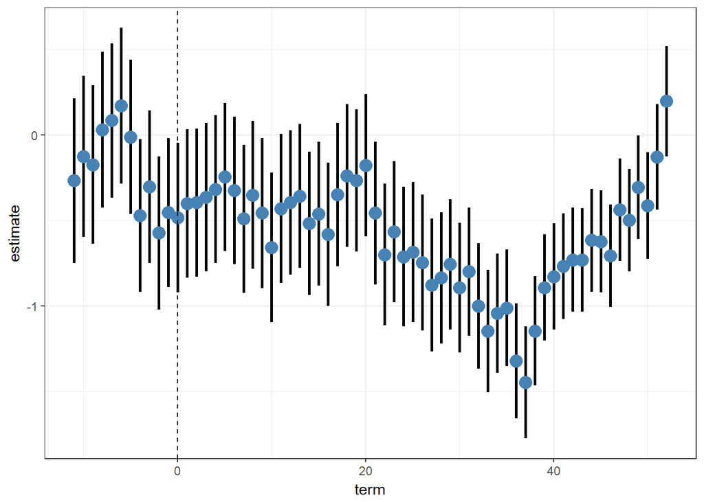

```r
broom::tidy(model8) %>%
  filter(grepl(pattern = "group1:as.factor", x = term)) %>%
  mutate(term = str_remove(term, "group1:as.factor\\(years_since\\)"),
         term = as.numeric(term)) %>%
  ggplot(aes(x = term, y = estimate)) +
  geom_errorbar(aes(ymin = estimate - std.error, ymax = estimate + std.error), width = 0, size = 1) +
  geom_point(color = "steelblue", size = 4) +
  theme_bw() +
  geom_vline(xintercept = 0, linetype = "dashed")
```

For years since tech advance

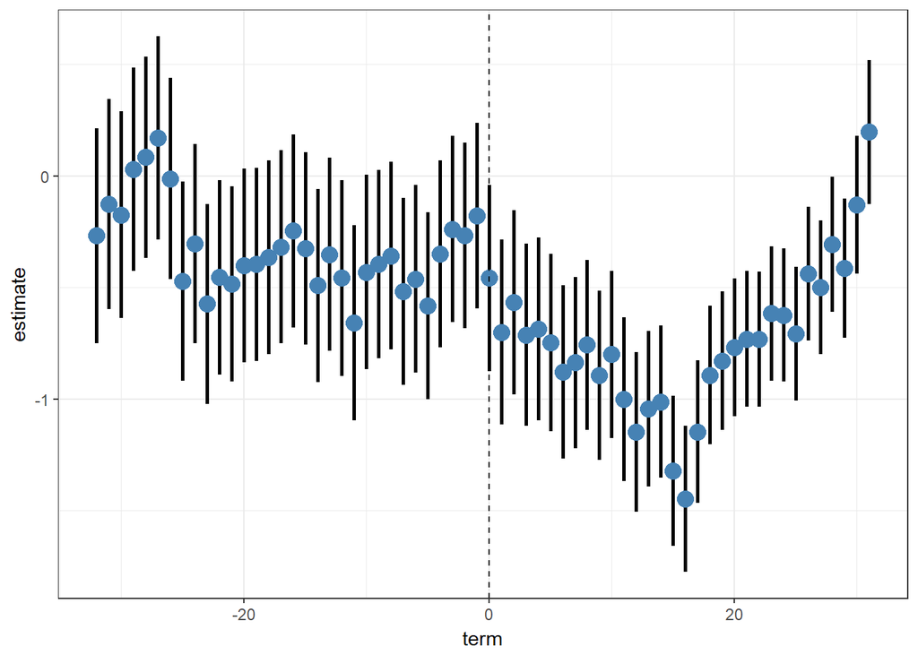

```r
broom::tidy(model9) %>%
  filter(grepl(pattern = "group1:as.factor", x = term)) %>%
  mutate(term = str_remove(term, "group1:as.factor\\(years_since_tech_improve\\)"),
         term = as.numeric(term)) %>%
  ggplot(aes(x = term, y = estimate)) +
  geom_errorbar(aes(ymin = estimate - std.error, ymax = estimate + std.error), width = 0, size = 1) +
  geom_point(color = "steelblue", size = 4) +
  theme_bw() +
  geom_vline(xintercept = 0, linetype = "dashed")
```

### Event-study plot

Aq starts in 1962

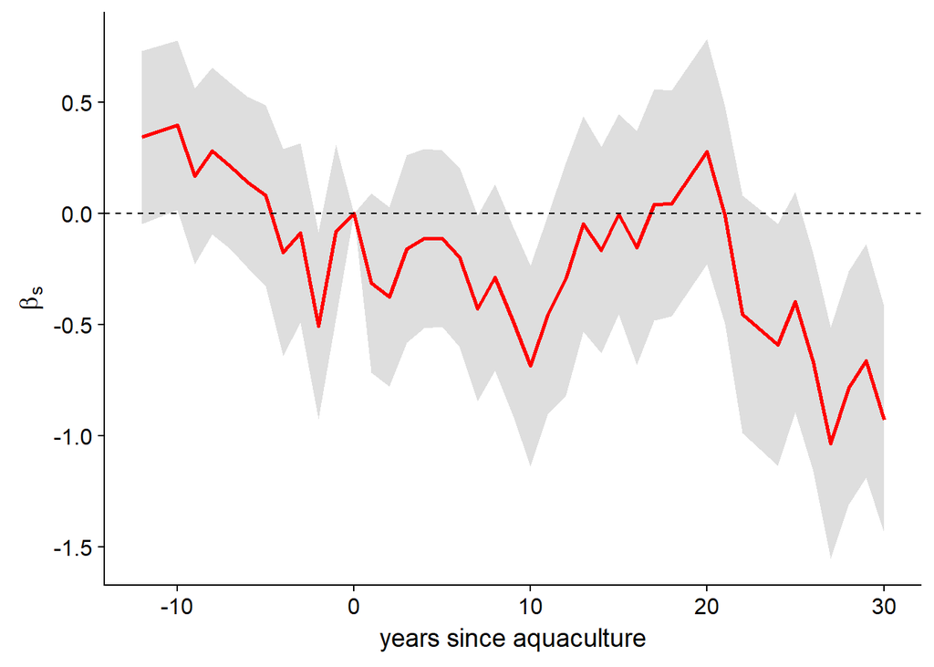

```r
T0 <- tibble(term = "group:T0", estimate = 0, std.error = 0, statistic = 0, p.value = NA, year = 0)

data_for_model_salmon_lobster %>%
  mutate(year = year - 1962,
         Tm12 = (year == -12)*1,
         Tm11 = (year == -12)*1,
         Tm10 = (year == -10)*1,
         Tm9 = (year == -9)*1,
         Tm8 = (year == -8)*1,
         Tm7 = (year == -7)*1,
         Tm6 = (year == -6)*1,
         Tm5 = (year == -5)*1,
         Tm4 = (year == -4)*1,
         Tm3 = (year == -3)*1,
         Tm2 = (year == -2)*1,
         Tm1 = (year == -1)*1,
         T0 = (year == 0)*1,
         T1 = (year == 1)*1,
         T2 = (year == 2)*1,
         T3 = (year == 3)*1,
         T4 = (year == 4)*1,
         T5 = (year == 5)*1,
         T6 = (year == 6)*1,
         T7 = (year == 7)*1,
         T8 = (year == 8)*1,
         T9 = (year == 9)*1,
         T10 = (year == 10)*1,
         T11 = (year == 11)*1,
         T12 = (year == 12)*1,
         T13 = (year == 13)*1,
         T14 = (year == 14)*1,
         T15 = (year == 15)*1,
         T16 = (year == 16)*1,
         T17 = (year == 17)*1,
         T18 = (year == 18)*1,
         T19 = (year == 19)*1,
         T20 = (year == 20)*1,
         T21 = (year == 21)*1,
         T22 = (year == 22)*1,
         T23 = (year == 23)*1,
         T24 = (year == 24)*1,
         T25 = (year == 25)*1,
         T26 = (year == 26)*1,
         T27 = (year == 27)*1,
         T28 = (year == 28)*1,
         T29 = (year == 29)*1,
         T30 = (year == 30)*1) %>%
  filter(dplyr::between(year, -12, 30)) %>%
  lm(formula = log(landings) ~ group_text*(Tm12 + Tm11 + Tm10 + Tm9 + Tm8 + Tm7 + Tm6 + Tm5 + Tm4 + Tm3 + Tm2 + Tm1 +T1 + T2 + T3 + T4 + T5 + T6 + T7 + T8 + T9 + T10 + T11 + T12 + T13 + T14 + T15 + T16 + T17 + T18 + T10 + T20 + T21 + T22 + T24 + T25 + T26 +T27 + T28 + T29 + T30) + group +  post + species + as.factor(year) -1, data = .) %>%
  lmtest::coeftest(plm::vcovHC(., type = "HC2", cluster = "species")) %>%
  broom::tidy() %>%
  filter(str_detect(string = term, pattern = "group_textSalmon:")) %>%
  mutate(year = substring(term, 19,21),
         year = gsub(pattern = "m", replacement = "-", year),
         year = as.numeric(year)) %>%
  rbind(T0) %>%
  ggplot(aes(x = year, y = estimate)) +
  geom_ribbon(aes(ymin = estimate - std.error, ymax = estimate + std.error), fill = "gray", alpha = 0.5) +
  geom_line(color = "red", size = 1) +
  cowplot::theme_cowplot() +
  geom_hline(yintercept = 0, linetype = "dashed") +
  labs(x = "years since aquaculture", y = bquote(beta[s]))
```

## Table

```r
stargazer::stargazer(model1, model2, model3, model4, model5, model6, model7, model8, model9,
                     single.row = T,
                     type = "html",
                     omit = c("country", "species", "year"),
                     intercept.bottom = F,
                     intercept.top = T)
```

|  | *Dependent variable:* |  |  |  |  |  |  |  |  |
| --- | --- | --- | --- | --- | --- | --- | --- | --- | --- |
|  | log(landings) |  |  |  |  |  |  |  |  |
|  | (1) | (2) | (3) | (4) | (5) | (6) | (7) | (8) | (9) |
| Constant | 5.980*** (0.169) | 4.386*** (0.223) | 6.041*** (0.427) | 4.396*** (0.307) | 4.353*** (0.303) | 4.196*** (0.227) | 4.091*** (0.222) | 4.031*** (0.310) | 4.031*** (0.310) |
| group1 | 2.055*** (0.211) | 2.331*** (0.162) | 2.153*** (0.211) | 2.367*** (0.161) | 2.391*** (0.159) | 1.983*** (0.159) | 1.910*** (0.157) | 2.203*** (0.363) | 2.203*** (0.363) |
| post | -0.341* (0.180) | 0.345*** (0.100) | 2.346*** (0.594) | 0.580* (0.326) | 0.450 (0.322) | -0.016 (0.241) | -0.058 (0.234) |  |  |
| aquaculture |  |  |  |  | -0.00000*** (0.00000) | -0.00000*** (0.00000) | -0.00000*** (0.00000) | -0.00000*** (0.00000) | -0.00000*** (0.00000) |
| price_per_ton_wild |  |  |  |  |  |  | 0.00002** (0.00001) |  |  |
| group1:post | -0.682*** (0.227) | -0.665*** (0.127) | -0.823*** (0.227) | -0.710*** (0.127) | -0.365*** (0.130) | -0.419*** (0.098) | -0.315*** (0.101) |  |  |
| Observations | 3,756 | 3,756 | 3,756 | 3,756 | 3,756 | 3,756 | 3,539 | 3,756 | 3,756 |
| R<sup>2</sup> | 0.103 | 0.744 | 0.144 | 0.753 | 0.760 | 0.865 | 0.869 | 0.869 | 0.869 |
| Adjusted R<sup>2</sup> | 0.103 | 0.740 | 0.128 | 0.745 | 0.751 | 0.860 | 0.864 | 0.862 | 0.862 |
| Residual Std. Error | 2.394 (df = 3752) | 1.288 (df = 3692) | 2.360 (df = 3687) | 1.277 (df = 3627) | 1.260 (df = 3626) | 0.944 (df = 3620) | 0.911 (df = 3407) | 0.940 (df = 3558) | 0.940 (df = 3558) |
| F Statistic | 143.986*** (df = 3; 3752) | 170.667*** (df = 63; 3692) | 9.094*** (df = 68; 3687) | 86.526*** (df = 128; 3627) | 88.928*** (df = 129; 3626) | 172.311*** (df = 135; 3620) | 172.089*** (df = 131; 3407) | 119.692*** (df = 197; 3558) | 119.692*** (df = 197; 3558) |
| *Note:* | p<0.1; p<0.05; p<0.01 |  |  |  |  |  |  |  |  |